# Investments

Week 3 – Tutorial 3  
Utz Weitzel & Eva Mynott – VU Finance

# Prepare session

In RStudio, open a project, or make a new one.

.

**Clear the console**

Ctrl + L (Windows) or Option + Command + L (iOS)

.

**Clear the environment**

```r
rm(list = ls(all.names = TRUE))
```

.

**Tidyverse package**

If you haven’t done so already, install the tidyverse package

```
install.packages("tidyverse") # once per machine
```

Load the tidyverse package

```r
library(tidyverse) # at the start of every session
options(dplyr.summarise.inform = FALSE)
```

.

.

# Importing data

We import data set `df303` with *monthly* data from 2018 to 2023 for all stocks (listed in `ticker` by `date`, `year`, and `month`) that are included in the S&P500 Index (as of March 2024, based on [this list](https://stockanalysis.com/list/sp-500-stocks/)) with *non-missing return data* for the last six years.

.

Compared to `df302`, this data set now also contains the SMB and HML factors, and quantile columns based on alpha, beta, std, and stde (constructed in Week 3 - Lecture 2).

.

```r
df303 = read_csv("df303.csv", show_col_types=FALSE)
```

.

We clean and sort the data set

```r
df303 = df303 |>
  arrange(ticker, date) # sort the data on ticker and date

View(df303)
```

.

.

# Portfolio wealth

.

Let’s assume we are at the *beginning* of our sample period and we want to invest 1,000 Euro.

.

We evaluate several different investment strategies: market neutral, long-only and 130-30. To determine the performance of each strategy, we look at the holding-period returns of each strategy.

.

First, let us calculate the average HPR of the highest (Q10) and lowest (Q1) beta quantiles.

```r
# Obtain the average holding period returns across stocks in the Q1 or Q10 decile
df303_ls = df303 |>
  group_by(q_beta) |>
  summarize(SP500_hpr_av = mean(SP500_hpr), # market hpr as benchmark
            rf_hpr_av = mean(rf_hpr),       # rf hpr as minimum
            re_hpr_av = mean(re_hpr)) |>    # mean hpr for cross-section of stocks
  filter(q_beta==1 | q_beta==10) # only keep quantiles 1 and 10

View(df303_ls)
```

.

## 1. Market-neutral

If we would have gone long in the top beta quantile (50% of our portfolio) and short in the bottom beta quantile (50% of our portfolio), with equal weights for stocks within each quantile, what would have been our *total* portfolio wealth at the end of the period?

.

```r
# Obtain long and short exposure
df303_ls = df303_ls |>
  mutate(long = subset(re_hpr_av, q_beta == 10)) |> # going long in Q10
  mutate(short = subset(re_hpr_av, q_beta == 1)) |> # going short in Q1
  mutate(long_short = long - short) |> # exposure = long - short (50-50)
  mutate(wealth_MN = 1000 * (1 + long_short)) # final wealth of this strategy

# Print the final wealth of this strategy
df303_ls |> select(long_short, wealth_MN) |> distinct() |> print()
```

```
# A tibble: 1 × 2
  long_short wealth_MN
       <dbl>     <dbl>
1      0.950     1950.
```

.

## 2. Long-only

A long-only portfolio is simply holding the portfolio with the highest signal value. A *signal* can be anything along which the stocks are ranked and grouped. We use beta.

.

We invest only in the highest beta stocks (Q10).

```r
# Going long in ONLY the Q10 beta portfolio
df303_ls = df303_ls |>
  mutate(wealth_L = 1000 * (1 + long))

# Print the final wealth of this strategy
df303_ls |> select(wealth_L) |> distinct() |> print()
```

```
# A tibble: 1 × 1
  wealth_L
     <dbl>
1    2661.
```

.

## 3. 130-30

A widely used fund strategy is long in 130% of the portfolio value of the stocks in the highest signal value portfolio and short in 30% of the total portfolio value among the lowest signal value stocks.

.

```r
# Investing 130% in Q10 (high beta) and -30% in Q1 (low beta)
df303_ls = df303_ls |>
  mutate(wealth_130_30 = 1000 * (1 + (1.3*long - 0.3*short)))

# Print the final wealth of this strategy
df303_ls |> select(wealth_130_30) |> distinct() |> print()
```

```
# A tibble: 1 × 1
  wealth_130_30
          <dbl>
1         2946.
```

We observe that strategy 3 (130-30) gives us the highest final wealth, followed by strategy 2 (long-only). Strategy 1 (market neutral) ranks third place.

.

.

# Extra: Out-of-sample performance

**Tip**

This part is optional. If you are interested, we examine the out-of-sample performance of several portfolios. We do so by combining the last R part of Lecture 2 with the Tutorial R code above.

.

What if we repeated the procedure of estimating quantiles (Lecture 2) on only the first half of the data? Let us call this the **in-sample period**, which consists of the first three years of data: 2018, 2019 and 2020.

.

Then we construct quantile portfolios based on the 2018-2020 estimates of alpha, beta, std, and sde. Now we will check the performance of these quantile portfolio **out-of-sample**, hence in 2021-2023.

.

We ask ourselves: *Do high alpha/beta/std/sde quantile portfolios based on the period 2018-2020 earn a higher average return in 2021-2023 (out-of-sample) as well?*

.

## Step 1: Define in-sample period

Define the in-sample period to be the first three years of data: 2018 - 2020.

```r
# Filter out the years 2018, 2019, 2020
df303_in = df303 |>
  filter(year == 2018 | year == 2019 | year == 2020) |>
  select(-re_hpr, -rf_hpr, -SP500_hpr, -q_alpha, -q_beta, -q_sdx, -q_sde, -beta, -rx_sd,   -sd_e, -rx_av, -rm_av) # remove earlier estimates from the entire sample
```

.

## Step 2: Define out-of-sample period

Define the out-of-sample period to be the last three years of data: 2021 - 2023.

```r
# Filter out the years 2021, 2022, 2023
df303_out = df303 |>
  filter(year == 2021 | year == 2022 | year == 2023) |>
  select(-re_hpr, -rf_hpr, -SP500_hpr, -q_alpha, -q_beta, -q_sdx, -q_sde, -beta, -rx_sd,   -sd_e, -rx_av, -rm_av) # remove earlier estimates from the entire sample
```

.

## Step 3: Estimate alpha, beta, std, sde (in-sample)

Estimate alpha, beta, std, sde in-sample (2018-2020) following the procedure of Lecture 2.

```r
# Obtain the avg market and excess returns, std, beta, and sde during 2018-2020
df303q_in = df303_in |>
  group_by(ticker) |> # do this for each stock (ticker)
  summarize(model = list(lm(rx ~ rm, data = pick(rx, rm))), # regression model
            rm_av = mean(rm, na.rm=T), # avg. market return
            rx_av = mean(rx, na.rm=T), # avg. stock return
            rx_sd = sd(rx, na.rm=T)) |>     # stock standard deviation
  mutate(alpha = map_dbl(model, ~ coef(.)[1])) |>     # alpha
  mutate(beta  = map_dbl(model, ~ coef(.)["rm"])) |>  # beta
  mutate(sd_e  = map_dbl(model, ~ sd(resid(.)))) |>   # sde
  select(-model)

View(df303q_in)
```

.

## Step 4: Construct in-sample quantiles

We construct quantiles based on the in-sample estimates (2018-2020)

```r
# Construct decile portfolio based on 2018-2023 betas, std, sde
df303q_in = df303q_in |>
  mutate(q_alpha = ntile(alpha, 10)) |> # high quantile = high value
  mutate(q_beta = ntile(beta, 10)) |>
  mutate(q_sdx  = ntile(rx_sd, 10)) |>
  mutate(q_sde  = ntile(sd_e, 10)) |>
  select(ticker, q_alpha, q_beta, q_sdx, q_sde) # drop unnecessary columns

View(df303q_in)
```

.

**Merge data**

Merge the out-of-sample data (2021-2023) with the estimated in-sample quantiles (2018-2020)

```r
# Merge by ticker
df303q <- merge(df303_out, df303q_in, by = c("ticker"))

View(df303q)
```

.

## Step 5: Calculate out-of-sample HPRs

Obtain holding period returns for each stock during the out-of-sample period (2021-2023)

```r
# For each stock, estimate holding period returns out-of-sample (2021-2023)
df303q = df303q |>
  group_by(ticker) |>
  summarize(SP500_hpr = prod(1+SP500, na.rm=T)-1, # market HPR
            re_hpr = prod(1+re, na.rm=T)-1,       # stock HPR
            rf_hpr = prod(1+rf, na.rm=T)-1,       # rf HPR
            rm_av = mean(rm, na.rm=T), # estimate average excess market returns
            rx_av = mean(rx, na.rm=T), # estimate average excess stock returns
            rx_sd = sd(rx, na.rm=T), # estimate standard deviations
            q_alpha = first(q_alpha), # keep the alpha quantiles
            q_beta = first(q_beta), # keep the beta quantiles
            q_sdx = first(q_sdx), # keep the sdx quantiles
            q_sde = first(q_sde)) # keep the sde quantiles

View(df303q)
```

.

## Step 6: Analyze results

We can now analyze the out-of-sample performance of the quantile portfolios that were constructed using in-sample data. Let us look at four different quantile portfolios.

.

**6.1 Q-Alpha in-sample vs. avg returns out-of-sample**

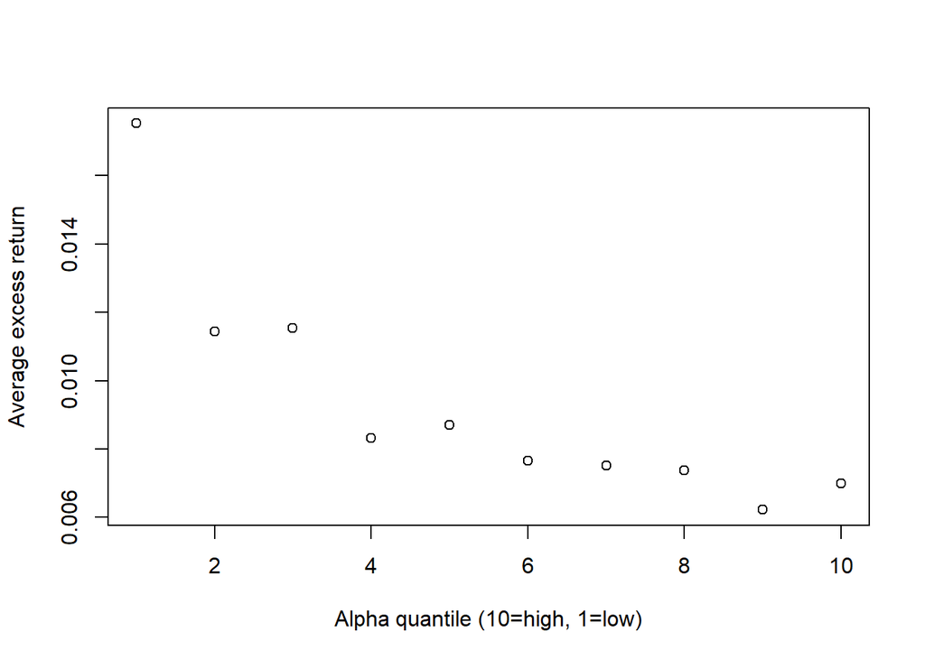

```r
df303q_alpha = df303q |>
  group_by(q_alpha) |>   # for all stocks in each of the ten alpha quantiles..
  summarize(mean_rx = mean(rx_av))  # .. we investigate the average excess return

plot(df303q_alpha$mean_rx, xlab = "Alpha quantile (10=high, 1=low)", ylab = "Average excess return")
```

.

**6.2 Q-Beta in-sample vs. avg returns out-of-sample**

*Is the average excess out-of-sample return higher for high-beta stocks (estimated in-sample)?*

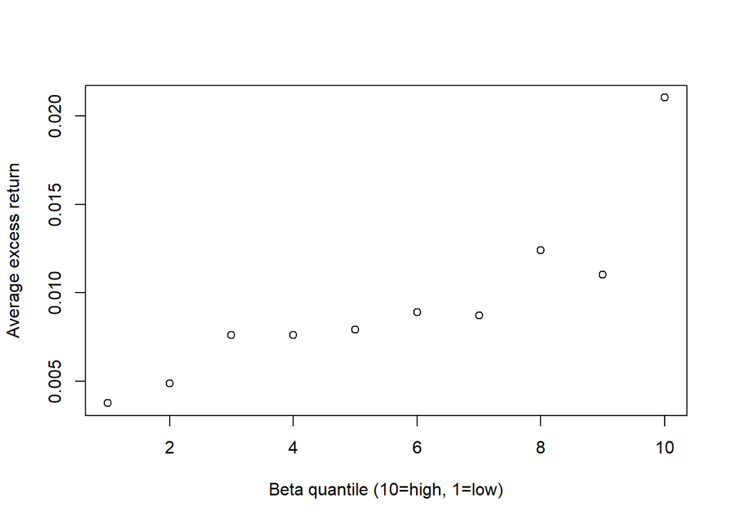

```r
df303q_beta = df303q |>
  group_by(q_beta) |> # for all stocks in each of the ten beta quantiles..
  summarize(mean_rx = mean(rx_av)) # .. we investigate the average excess return

plot(df303q_beta$mean_rx, xlab = "Beta quantile (10=high, 1=low)", ylab = "Average excess return")
```

.

**6.3 Q-Std in-sample vs. avg returns out-of-sample**

*Is the average excess out-of-sample return higher for high-std stocks (estimated in-sample)?*

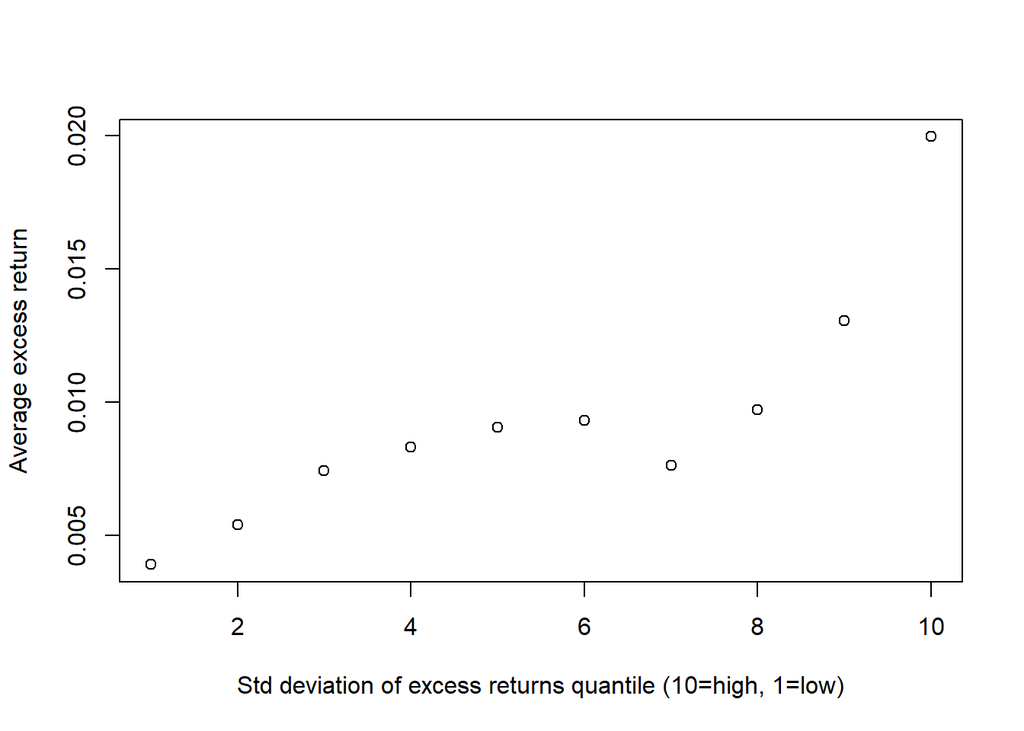

```r
df303q_std = df303q |>
  group_by(q_sdx) |> # for all stocks in each of the ten sdx quantiles..
  summarize(mean_rx = mean(rx_av)) # .. we investigate the average excess return

plot(df303q_std$mean_rx, xlab = "Std deviation of excess returns quantile (10=high, 1=low)", ylab = "Average excess return")
```

.

**6.4 Q-Sde in-sample vs. avg returns out-of-sample**

*Is the average excess out-of-sample return higher for high-sde stocks (estimated in-sample)?*

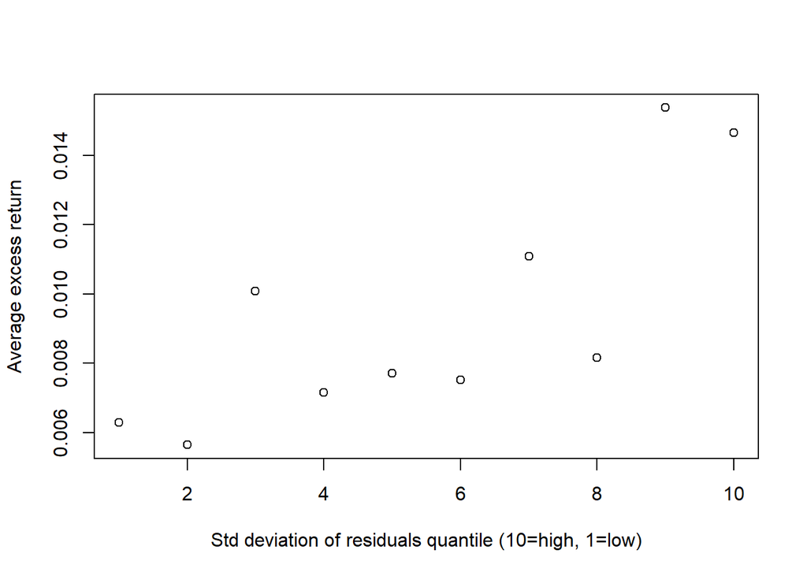

```r
df303q_sde = df303q |>
  group_by(q_sde) |> # for all stocks in each of the ten sde quantiles..
  summarize(mean_rx = mean(rx_av)) # .. we investigate the average excess return

plot(df303q_sde$mean_rx, xlab = "Std deviation of residuals quantile (10=high, 1=low)", ylab = "Average excess return")
```

.

**Conclusion:** High beta and high std quantile portfolios based on the in-sample data (2018-2020) also earn a higher average return out-of-sample! The effect for the sde portfolios has become weaker out-of-sample, although we can still roughly say that high sde portfolios in-sample earn a higher average return out-of-sample. For high alpha quantile portfolios, the effect is now opposite out-of-sample: portfolios that earned a high alpha in the in-sample period perform poorly out-of-sample.